# RPS Model Creation

## Preparing the environment

We require a corpus of training data to help build our model. Quite fortunately for us someone has already created one for us on Kaggle.

https://www.kaggle.com/alishmanandhar/rock-scissor-paper

A login is required to download this, so we uploaded it to S3 earlier to simplify things.

First thing we need to do is download it to our instance and unzip it.

```python
import boto3

bucket = 'ac3-sumerian-rps-sagemaker'

boto3.resource('s3').Bucket(bucket).download_file('final.zip', 'final.zip')

!unzip -q -o final.zip
```

This is python by default. An ! causes a shell command to run

```python
!ls
```

```
final  final.zip  lost+found  notebook.ipynb
```

or you could use a bash section instead

```python
%%bash
ls -l
```

```
total 255984
drwxrwxr-x 4 ec2-user ec2-user      4096 Aug 24  2018 final
-rw-rw-r-- 1 ec2-user ec2-user 260637948 Jun 23 06:03 final.zip
drwx------ 2 root     root         16384 Jun 23 05:46 lost+found
-rw-rw-r-- 1 ec2-user ec2-user   1462928 Jun 23 06:05 notebook.ipynb
```

or even ruby and others!

```python
%%ruby
5.times { puts 'Hello!' }
```

```
Hello!
Hello!
Hello!
Hello!
Hello!
```

By default SageMaker notebook seem to default to using MXNet for keras. We fix this by moving the config file out of the way.

*NB* OK maybe this isn't needed anymore??

```python
!mv ~/.keras/keras.json keras_tensorflow.json
```

```
mv: cannot stat ‘/home/ec2-user/.keras/keras.json’: No such file or directory
```

## Explore the data

Let's take a look at the training and validation data

```python
%%bash

echo
echo "What is in final"
ls final
echo "========================="
echo
cd final


echo "What is in the train dir"
ls train | head
echo "========================="
echo

echo "What is in the train/c0 dir"
ls train/c0 | head -5
echo
echo "========================="
echo

echo "How many train files"
ls -1R train | wc -l
echo "========================="
echo

echo "How many valid files"
ls -1R valid | wc -l
```

```
What is in final
train
valid
=========================

What is in the train dir
c0
c1
c2
=========================

What is in the train/c0 dir
2017-03-30 07.05.31.jpg
2017-03-30 07.05.49.jpg
2017-03-30 07.33.21.jpg
2017-04-04 18.55.54.jpg
2017-04-04 18.56.04.jpg

=========================

How many train files
2330
=========================

How many valid files
103
```

## Set up python

Import a bunch of libraries we'll need later

```python
from keras import models
from keras import layers
from keras import optimizers
from keras.applications import MobileNetV2
from keras.preprocessing.image import ImageDataGenerator
from keras.callbacks import ModelCheckpoint, TensorBoard

import os
```

## Do some tuning

### batch_size

- 32 seems to work - ML Black magic
- Other good values 64 and 128
- The bigger the batch size the more memory you need

### epochs

- from testing 20 seems to be more than sufficient to get good results
- deminishing returns after that
- The more epochs the longer the training takes

### classes

- We have three
- Rock, Paper and Scissors

```python
batch_size = 32
epochs = 20
classes = 3
```

## Load the model

We want to use MobileNet v2 as our model. Our input shape is 224, 224, 3

- width
- height
- number of channels
- We don't include the top layer as we are going to replace it

We load the **ImageNet** weights as we are going to do tranfer learning

This will load the model and download the weights.

```python
conv_base = MobileNetV2(
    input_shape=(224, 224, 3),
    weights='imagenet',
    include_top=False,
)
conv_base.trainable = True
conv_base.summary()
```

```
__________________________________________________________________________________________________
Layer (type)                    Output Shape         Param #     Connected to
==================================================================================================
input_2 (InputLayer)            (None, 224, 224, 3)  0
__________________________________________________________________________________________________
Conv1_pad (ZeroPadding2D)       (None, 225, 225, 3)  0           input_2[0][0]
__________________________________________________________________________________________________
Conv1 (Conv2D)                  (None, 112, 112, 32) 864         Conv1_pad[0][0]
__________________________________________________________________________________________________
bn_Conv1 (BatchNormalization)   (None, 112, 112, 32) 128         Conv1[0][0]
__________________________________________________________________________________________________
Conv1_relu (ReLU)               (None, 112, 112, 32) 0           bn_Conv1[0][0]
__________________________________________________________________________________________________
expanded_conv_depthwise (Depthw (None, 112, 112, 32) 288         Conv1_relu[0][0]
__________________________________________________________________________________________________
expanded_conv_depthwise_BN (Bat (None, 112, 112, 32) 128         expanded_conv_depthwise[0][0]
__________________________________________________________________________________________________
expanded_conv_depthwise_relu (R (None, 112, 112, 32) 0           expanded_conv_depthwise_BN[0][0]
__________________________________________________________________________________________________
expanded_conv_project (Conv2D)  (None, 112, 112, 16) 512         expanded_conv_depthwise_relu[0][0
__________________________________________________________________________________________________
expanded_conv_project_BN (Batch (None, 112, 112, 16) 64          expanded_conv_project[0][0]
__________________________________________________________________________________________________
block_1_expand (Conv2D)         (None, 112, 112, 96) 1536        expanded_conv_project_BN[0][0]
__________________________________________________________________________________________________
block_1_expand_BN (BatchNormali (None, 112, 112, 96) 384         block_1_expand[0][0]
__________________________________________________________________________________________________
block_1_expand_relu (ReLU)      (None, 112, 112, 96) 0           block_1_expand_BN[0][0]
__________________________________________________________________________________________________
block_1_pad (ZeroPadding2D)     (None, 113, 113, 96) 0           block_1_expand_relu[0][0]
__________________________________________________________________________________________________
block_1_depthwise (DepthwiseCon (None, 56, 56, 96)   864         block_1_pad[0][0]
__________________________________________________________________________________________________
block_1_depthwise_BN (BatchNorm (None, 56, 56, 96)   384         block_1_depthwise[0][0]
__________________________________________________________________________________________________
block_1_depthwise_relu (ReLU)   (None, 56, 56, 96)   0           block_1_depthwise_BN[0][0]
__________________________________________________________________________________________________
block_1_project (Conv2D)        (None, 56, 56, 24)   2304        block_1_depthwise_relu[0][0]
__________________________________________________________________________________________________
block_1_project_BN (BatchNormal (None, 56, 56, 24)   96          block_1_project[0][0]
```

[output cut: 272 more lines]

```
__________________________________________________________________________________________________
block_16_project (Conv2D)       (None, 7, 7, 320)    307200      block_16_depthwise_relu[0][0]
__________________________________________________________________________________________________
block_16_project_BN (BatchNorma (None, 7, 7, 320)    1280        block_16_project[0][0]
__________________________________________________________________________________________________
Conv_1 (Conv2D)                 (None, 7, 7, 1280)   409600      block_16_project_BN[0][0]
__________________________________________________________________________________________________
Conv_1_bn (BatchNormalization)  (None, 7, 7, 1280)   5120        Conv_1[0][0]
__________________________________________________________________________________________________
out_relu (ReLU)                 (None, 7, 7, 1280)   0           Conv_1_bn[0][0]
==================================================================================================
Total params: 2,257,984
Trainable params: 2,223,872
Non-trainable params: 34,112
__________________________________________________________________________________________________
```

## Prepare a new model

**NB:** This is where the black magic starts

- Create a new sequential model
- Add mobilenet that we loaded in to it
- Flatten
  - flatten stuff???
- Dense
  - Why 256?
  - tanh is one option others are rreli, prelu
- Dense
  - We want only 3 outputs at the end
  - sigmoid is a good function softmax is another
- Print out the summary

```python
model = models.Sequential()
model.add(conv_base)
model.add(layers.Flatten())
model.add(layers.Dense(256, activation='tanh')) # relu (maybe rrelu or prelu will solve dying issue) could also use sigmoid or tanh
model.add(layers.Dense(classes, activation='sigmoid')) # try softmax
model.summary()
```

```
_________________________________________________________________
Layer (type)                 Output Shape              Param #
=================================================================
mobilenetv2_1.00_224 (Model) (None, 7, 7, 1280)        2257984
_________________________________________________________________
flatten_2 (Flatten)          (None, 62720)             0
_________________________________________________________________
dense_3 (Dense)              (None, 256)               16056576
_________________________________________________________________
dense_4 (Dense)              (None, 3)                 771
=================================================================
Total params: 18,315,331
Trainable params: 18,281,219
Non-trainable params: 34,112
_________________________________________________________________
```

- trainable - renables training for the original model
- We compile the model
  - RMSprop is an opitimizer function which helps
  - loss - function to measure the loss
  - metrics - the ones we care about

```python
model.compile(optimizer=optimizers.RMSprop(lr=2e-5), # Adam?
              loss='categorical_crossentropy',
              metrics=['acc'])
```

## Prepare the training data

- Load in the training data
- We do lots of permutations on the data to get even more data
- We also load the validation data in.
- We do not manipulate it, only load it to a consistent size

```python
base_dir = 'final'
train_dir = os.path.join(base_dir, 'train')
validation_dir = os.path.join(base_dir, 'valid')
train_datagen = ImageDataGenerator(
    rescale=1. / 255,
    rotation_range=40,
    width_shift_range=0.2,
    height_shift_range=0.2,
    shear_range=0.2,
    zoom_range=0.2,
    horizontal_flip=True,
    vertical_flip=True,
)
validation_datagen = ImageDataGenerator(
    rescale=1. / 255,
)
train_generator = train_datagen.flow_from_directory(
        train_dir,
        target_size=(224, 224),
        batch_size=batch_size,
        class_mode='categorical'
)

validation_generator = validation_datagen.flow_from_directory(
        validation_dir,
        target_size=(224, 224),
        batch_size=batch_size,
        class_mode='categorical'
)
```

```
Found 2320 images belonging to 3 classes.
Found 93 images belonging to 3 classes.
```

## Set up checkpoint

Next we set up a checkpoint. This will save a copy of the model but only if the accuracy is improving.

```python
filepath="rps-keras-{epoch:02d}-{val_acc:.2f}.hdf5"
checkpoint = ModelCheckpoint(
    filepath,
    monitor='val_acc',
    verbose=1,
    save_best_only=True,
    mode='max'
)

# TODO: Add earlystop
callbacks = [checkpoint]

step_size_train = train_generator.n // train_generator.batch_size
step_size_valid = validation_generator.n // validation_generator.batch_size
```

## Hammer time

We now run the model passing it everything we have prepared earlier

```python
history = model.fit_generator(
      train_generator,
      steps_per_epoch=step_size_train,
      epochs=epochs,
      callbacks=callbacks,
      validation_data=validation_generator,
      validation_steps=step_size_valid,
      verbose=2)
print('DONE')
```

```
WARNING:tensorflow:From /home/ec2-user/anaconda3/envs/tensorflow_p36/lib/python3.6/site-packages/tensorflow/python/ops/math_ops.py:3066: to_int32 (from tensorflow.python.ops.math_ops) is deprecated and will be removed in a future version.
Instructions for updating:
Use tf.cast instead.
 - 61s - loss: 0.8260 - acc: 0.6063 - val_loss: 0.4311 - val_acc: 0.8438

Epoch 00001: val_acc improved from -inf to 0.84375, saving model to rps-keras-01-0.84.hdf5
 - 34s - loss: 0.5447 - acc: 0.7800 - val_loss: 0.2691 - val_acc: 0.9016

Epoch 00002: val_acc improved from 0.84375 to 0.90164, saving model to rps-keras-02-0.90.hdf5
 - 38s - loss: 0.3979 - acc: 0.8459 - val_loss: 0.2697 - val_acc: 0.9016

Epoch 00003: val_acc did not improve from 0.90164
 - 39s - loss: 0.3134 - acc: 0.8780 - val_loss: 0.1466 - val_acc: 0.9375

Epoch 00004: val_acc improved from 0.90164 to 0.93750, saving model to rps-keras-04-0.94.hdf5
 - 38s - loss: 0.2998 - acc: 0.8967 - val_loss: 0.1022 - val_acc: 0.9672

Epoch 00005: val_acc improved from 0.93750 to 0.96721, saving model to rps-keras-05-0.97.hdf5
 - 38s - loss: 0.2518 - acc: 0.9123 - val_loss: 0.1032 - val_acc: 0.9672

Epoch 00006: val_acc improved from 0.96721 to 0.96721, saving model to rps-keras-06-0.97.hdf5
 - 39s - loss: 0.2057 - acc: 0.9223 - val_loss: 0.0939 - val_acc: 0.9688

Epoch 00007: val_acc improved from 0.96721 to 0.96875, saving model to rps-keras-07-0.97.hdf5
 - 39s - loss: 0.2099 - acc: 0.9253 - val_loss: 0.1461 - val_acc: 0.9180

Epoch 00008: val_acc did not improve from 0.96875
 - 39s - loss: 0.1927 - acc: 0.9319 - val_loss: 0.0287 - val_acc: 1.0000

Epoch 00009: val_acc improved from 0.96875 to 1.00000, saving model to rps-keras-09-1.00.hdf5
 - 39s - loss: 0.1721 - acc: 0.9405 - val_loss: 0.1001 - val_acc: 0.9688

Epoch 00010: val_acc did not improve from 1.00000
 - 39s - loss: 0.1742 - acc: 0.9414 - val_loss: 0.0368 - val_acc: 0.9836

Epoch 00011: val_acc did not improve from 1.00000
 - 39s - loss: 0.1556 - acc: 0.9457 - val_loss: 0.1110 - val_acc: 0.9508

Epoch 00012: val_acc did not improve from 1.00000
 - 40s - loss: 0.1327 - acc: 0.9553 - val_loss: 0.0995 - val_acc: 0.9531
```

[output cut: 9 more lines]

```

Epoch 00016: val_acc did not improve from 1.00000
 - 39s - loss: 0.1143 - acc: 0.9592 - val_loss: 0.0979 - val_acc: 0.9344

Epoch 00017: val_acc did not improve from 1.00000
 - 39s - loss: 0.1027 - acc: 0.9696 - val_loss: 0.0222 - val_acc: 1.0000

Epoch 00018: val_acc did not improve from 1.00000
 - 38s - loss: 0.0894 - acc: 0.9735 - val_loss: 0.0487 - val_acc: 0.9844

Epoch 00019: val_acc did not improve from 1.00000
 - 39s - loss: 0.1091 - acc: 0.9635 - val_loss: 0.0705 - val_acc: 0.9672

Epoch 00020: val_acc did not improve from 1.00000
DONE
```

## How did we go??

One of the great things about Notebook us being able to display images and matlab plots inline.

Now we can plot how our training went

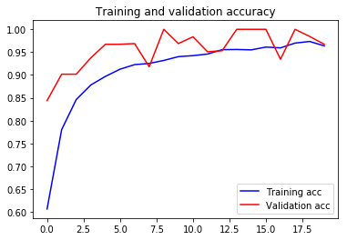

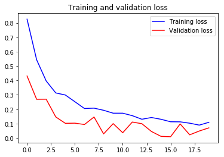

```python
%matplotlib inline

from matplotlib import pyplot as plt


acc = history.history['acc']
val_acc = history.history['val_acc']
loss = history.history['loss']
val_loss = history.history['val_loss']

epochs = range(len(acc))

plt.plot(epochs, acc, 'b', label='Training acc')
plt.plot(epochs, val_acc, 'r', label='Validation acc')
plt.title('Training and validation accuracy')
plt.legend()

plt.figure()

plt.plot(epochs, loss, 'b', label='Training loss')
plt.plot(epochs, val_loss, 'r', label='Validation loss')
plt.title('Training and validation loss')
plt.legend()

plt.show()
```

## Play with our model

Let's run the model against the validation data and check any bad results

```
Found 93 images belonging to 3 classes.
No of errors = 1/93
```

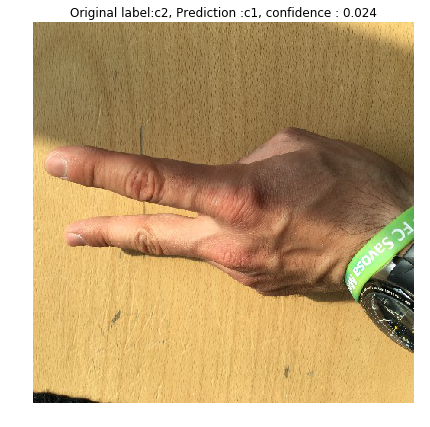

```python
import numpy as np
import matplotlib.image as mpimg

def load_img(filename):
    return mpimg.imread(filename)

# Create a generator for prediction
validation_generator = validation_datagen.flow_from_directory(
        validation_dir,
        target_size=(224, 224),
        batch_size=batch_size,
        class_mode='categorical',
        shuffle=False)

# Get the filenames from the generator
fnames = validation_generator.filenames

# Get the ground truth from generator
ground_truth = validation_generator.classes

# Get the label to class mapping from the generator
label2index = validation_generator.class_indices

# Getting the mapping from class index to class label
idx2label = dict((v,k) for k,v in label2index.items())

# Get the predictions from the model using the generator
predictions = model.predict_generator(validation_generator, steps=validation_generator.samples/validation_generator.batch_size,verbose=1)
predicted_classes = np.argmax(predictions,axis=1)

errors = np.where(predicted_classes != ground_truth)[0]
print("No of errors = {}/{}".format(len(errors),validation_generator.samples))

# Show the errors
for i in range(len(errors)):
    pred_class = np.argmax(predictions[errors[i]])
    pred_label = idx2label[pred_class]

    title = 'Original label:{}, Prediction :{}, confidence : {:.3f}'.format(
        fnames[errors[i]].split('/')[0],
        pred_label,
        predictions[errors[i]][pred_class])

    original = load_img('{}/{}'.format(validation_dir,fnames[errors[i]]))
    plt.figure(figsize=[7,7])
    plt.axis('off')
    plt.title(title)
    plt.imshow(original)
    plt.show()
```

## What about the training data

Let's do the same

```python
import numpy as np
import matplotlib.image as mpimg

def load_image(filename):
    return mpimg.imread('filename')

train_generator = train_datagen.flow_from_directory(
        train_dir,
        target_size=(224, 224),
        batch_size=batch_size,
        class_mode='categorical',
        shuffle=False)

# Get the ground truth from generator
ground_truth = validation_generator.classes

# Get the label to class mapping from the generator
label2index = validation_generator.class_indices

# Getting the mapping from class index to class label
idx2label = dict((v,k) for k,v in label2index.items())

# Get the predictions from the model using the generator
predictions = model.predict_generator(train_generator, steps=train_generator.samples/train_generator.batch_size,verbose=1)
predicted_classes = np.argmax(predictions,axis=1)

errors = np.where(predicted_classes != ground_truth)[0]
print("No of errors = {}/{}".format(len(errors),train_generator.samples))
```

```
Found 2320 images belonging to 3 classes.
No of errors = 1/2320
```

[figure not shown]

```python
# Show the errors
for i in range(len(errors)):
  pred_class = np.argmax(predictions[errors[i]])
  pred_label = idx2label[pred_class]

  title = 'Original label:{}, Prediction :{}, confidence : {:.3f}'.format(
    fnames[errors[i]].split('/')[0],
    pred_label,
    predictions[errors[i]][pred_class])

  original = load_img('{}/{}'.format(validation_dir,fnames[errors[i]]))
  plt.figure(figsize=[7,7])
  plt.axis('off')
  plt.title(title)
  plt.imshow(original)
  plt.show()
```

## We are done

Save the model and upload everything into S3

```python
model.save('rps-keras-final.hdf5')

!ls -ltr

## Load libraries again in case we are running things out of order
import boto3
from pathlib import Path

bucket = 'ac3-sumerian-rps-sagemaker'

pathlist = Path('.').glob('*.hdf5')
for path in pathlist:
     boto3.resource('s3').Bucket(bucket).upload_file(str(path), 'keras/{}'.format(str(path)))
```

```
total 1401692
drwxrwxr-x 4 ec2-user ec2-user      4096 Aug 24  2018 final
drwx------ 2 root     root         16384 Jun 23 05:46 lost+found
-rw-rw-r-- 1 ec2-user ec2-user        32 Jun 23 05:49 keras_tensorflow.json
-rw-rw-r-- 1 ec2-user ec2-user 260637948 Jun 23 06:03 final.zip
-rw-rw-r-- 1 ec2-user ec2-user 146754512 Jun 23 06:42 rps-keras-01-0.84.hdf5
-rw-rw-r-- 1 ec2-user ec2-user 146754512 Jun 23 06:42 rps-keras-02-0.90.hdf5
-rw-rw-r-- 1 ec2-user ec2-user 146754512 Jun 23 06:44 rps-keras-04-0.94.hdf5
-rw-rw-r-- 1 ec2-user ec2-user 146754512 Jun 23 06:44 rps-keras-05-0.97.hdf5
-rw-rw-r-- 1 ec2-user ec2-user 146754512 Jun 23 06:45 rps-keras-06-0.97.hdf5
-rw-rw-r-- 1 ec2-user ec2-user 146754512 Jun 23 06:46 rps-keras-07-0.97.hdf5
-rw-rw-r-- 1 ec2-user ec2-user 146754512 Jun 23 06:47 rps-keras-09-1.00.hdf5
-rw-rw-r-- 1 ec2-user ec2-user    618521 Jun 23 07:03 notebook.ipynb
-rw-rw-r-- 1 ec2-user ec2-user 146754512 Jun 23 07:03 rps-keras-final.hdf5
```

# GO BACK TO YOUR ORIGINAL SCRIPT AND STOP THE NOTEBOOK